# Case Study 2

Meraj

2023-11-27

```r
# Load libraries
suppressPackageStartupMessages(library(tidyverse))
suppressPackageStartupMessages(library(gridExtra))
suppressPackageStartupMessages(library(knitr))
suppressPackageStartupMessages(library(e1071))
suppressPackageStartupMessages(library(caret))
suppressPackageStartupMessages(library(class))
suppressPackageStartupMessages(library(readxl))
```

1. Data Preprocessing & Exploration

```r
# Load the dataset
data <- read.csv("CaseStudy2-data.csv")

# Explore the structure of the dataset
str(data)
```

```
## 'data.frame':    870 obs. of  36 variables:
##  $ ID                      : int  1 2 3 4 5 6 7 8 9 10 ...
##  $ Age                     : int  32 40 35 32 24 27 41 37 34 34 ...
##  $ Attrition               : chr  "No" "No" "No" "No" ...
##  $ BusinessTravel          : chr  "Travel_Rarely" "Travel_Rarely" "Travel_Frequently" "Travel_Rarely" ...
##  $ DailyRate               : int  117 1308 200 801 567 294 1283 309 1333 653 ...
##  $ Department              : chr  "Sales" "Research & Development" "Research & Development" "Sales" ...
##  $ DistanceFromHome        : int  13 14 18 1 2 10 5 10 10 10 ...
##  $ Education               : int  4 3 2 4 1 2 5 4 4 4 ...
##  $ EducationField          : chr  "Life Sciences" "Medical" "Life Sciences" "Marketing" ...
##  $ EmployeeCount           : int  1 1 1 1 1 1 1 1 1 1 ...
##  $ EmployeeNumber          : int  859 1128 1412 2016 1646 733 1448 1105 1055 1597 ...
##  $ EnvironmentSatisfaction : int  2 3 3 3 1 4 2 4 3 4 ...
##  $ Gender                  : chr  "Male" "Male" "Male" "Female" ...
##  $ HourlyRate              : int  73 44 60 48 32 32 90 88 87 92 ...
```

[output cut: 22 more lines]

```r
# Check for missing values
sum(is.na(data)) # no missing
```

```
## [1] 0
```

2. Boxplots of Numeric Variables Grouped by Attrition

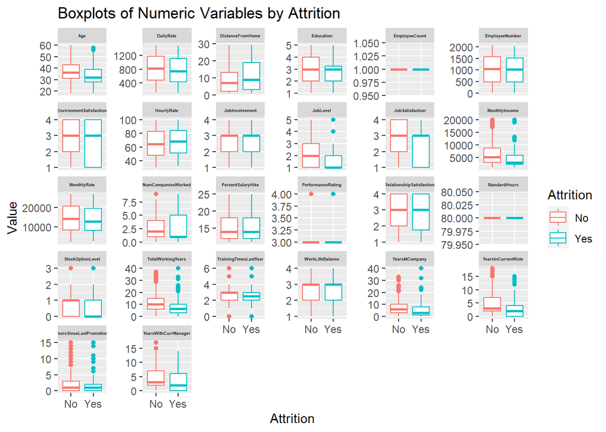

```r
# Select numeric variables except ID
numeric_vars <- data %>% select_if(is.numeric) %>% select(-ID)

# Melt data for boxplot plotting
melted_data <- numeric_vars %>%
  mutate(Attrition = data$Attrition) %>%
  gather(variable, value, -Attrition)

# Create boxplots
ggplot(melted_data, aes(x = Attrition, y = value, color = Attrition)) +
  geom_boxplot() +
  facet_wrap(~variable, scales = "free_y") +
  labs(x = "Attrition", y = "Value", title = "Boxplots of Numeric Variables by Attrition") +
  theme(strip.text = element_text(size = 3.5, face = "bold"))
```

```r
# Calculate mean values by Attrition
mean_values <- numeric_vars %>%
  mutate(Attrition = data$Attrition) %>%
  group_by(Attrition) %>%
  summarise(across(everything(), \(x) mean(x, na.rm = TRUE)))

mean_values <- data.frame(t(mean_values))
mean_values <- mean_values[-1, ]
colnames(mean_values) <- c("Attrition=No", "Attrition=Yes")
mean_values <- mean_values %>% mutate_if(is.character, as.numeric)
# Calculate the relative difference in the mean of each numeric variables grouped by attrition(use attrition = No as the reference)

mean_values$RelativeDiff <- ((mean_values$`Attrition=Yes` - mean_values$`Attrition=No`) / mean_values$`Attrition=No`) * 100
mean_values <- round(mean_values, 2)

# Select the top 5 variables that has the largest relative difference
sorted_mean_values <- mean_values %>% arrange(desc(abs(RelativeDiff)))

# Display the result
kable(sorted_mean_values[which(abs(sorted_mean_values$RelativeDiff)>=10),], caption = "The top 11 numeric variables displaying relative differences of at least 10%")
```

The top 11 numeric variables displaying relative differences of at least 10%

|  | Attrition=No | Attrition=Yes | RelativeDiff |
| --- | --- | --- | --- |
| StockOptionLevel | 0.84 | 0.49 | -41.31 |
| YearsInCurrentRole | 4.45 | 2.91 | -34.72 |
| YearsWithCurrManager | 4.37 | 2.94 | -32.66 |
| TotalWorkingYears | 11.60 | 8.19 | -29.45 |
| MonthlyIncome | 6702.00 | 4764.79 | -28.91 |
| YearsAtCompany | 7.30 | 5.19 | -28.88 |
| JobLevel | 2.12 | 1.64 | -22.71 |
| DistanceFromHome | 9.03 | 10.96 | 21.36 |
| NumCompaniesWorked | 2.66 | 3.08 | 15.72 |
| JobInvolvement | 2.78 | 2.42 | -12.92 |
| JobSatisfaction | 2.76 | 2.44 | -11.80 |

From the boxplots and the summary table of means, noticeable disparities emerge in the distributions and means of “StockOptionLevel,” “YearsInCurrentRole,” “YearsWithCurrManager,” “TotalWorkingYears,” and “MonthlyIncome” when grouped by attrition status. Indicating those 5 variables may be the key factors that cause “Attrition”.

3. Chi-Square Test of Independence for Categorical Variables

```r
# Select categorical variables, remove Over18 since everyone in the data set is over 18.
char_columns <- colnames(data %>% select_if(is.character))[-c(1,8)]

# Chi-square test for independence for categorical variables
p_values_chi <- c()
for (i in 1:length(char_columns)){
  var = char_columns[i]
  contingency_table <- table(Variable = data[, var], Attrition = data$Attrition)
  PropOfAttrition <- as.vector(round(contingency_table[, 2]/(contingency_table[, 1]+contingency_table[,2]), 3))
  show_tab <- cbind(contingency_table, PropOfAttrition)
  cat("For ", var, "\n")
  print(show_tab)
  cat("**************************", "\n")
  chisq_test <- chisq.test(contingency_table)
  p_values_chi[i] <- round(chisq_test$p.value, 4)
}
```

```
## For  BusinessTravel
##                    No Yes PropOfAttrition
## Non-Travel         83  11           0.117
## Travel_Frequently 123  35           0.222
## Travel_Rarely     524  94           0.152
## For  Department
##                         No Yes PropOfAttrition
## Human Resources         29   6           0.171
## Research & Development 487  75           0.133
## Sales                  214  59           0.216
## For  EducationField
##                   No Yes PropOfAttrition
## Human Resources   11   4           0.267
## Life Sciences    305  53           0.148
## Marketing         80  20           0.200
## Medical          233  37           0.137
## Other             43   9           0.173
## Technical Degree  58  17           0.227
## For  Gender
##         No Yes PropOfAttrition
## Female 301  53           0.150
## Male   429  87           0.169
## For  JobRole
##                            No Yes PropOfAttrition
## Healthcare Representative  68   8           0.105
## Human Resources            21   6           0.222
## Laboratory Technician     123  30           0.196
## Manager                    47   4           0.078
## Manufacturing Director     85   2           0.023
## Research Director          50   1           0.020
## Research Scientist        140  32           0.186
## Sales Executive           167  33           0.165
## Sales Representative       29  24           0.453
## For  MaritalStatus
##           No Yes PropOfAttrition
## Divorced 179  12           0.063
## Married  352  58           0.141
## Single   199  70           0.260
## For  OverTime
##      No Yes PropOfAttrition
## No  558  60           0.097
## Yes 172  80           0.317
```

```r
chi_test_df <- t(data.frame(Variable = char_columns, P_value = p_values_chi))
rownames(chi_test_df) <- NULL
# Print the p-values table
kable(chi_test_df, caption = "P-values of Chi-Square Test of Independence with Attrition")
```

P-values of Chi-Square Test of Independence with Attrition

| BusinessTravel | Department | EducationField | Gender | JobRole | MaritalStatus | OverTime |
| --- | --- | --- | --- | --- | --- | --- |
| 0.0499 | 0.0094 | 0.2682 | 0.5151 | 0.0000 | 0.0000 | 0.0000 |

Based on the p-values and the contingency tables, we see that there are higher proportions of attrition among people with overtime and those who work as sales representatives. Thus, the variable “OverTime” and “JobRole” are highly related with attrition.

4. The Top 3 Factors

“StockOptionLevel,” “YearsInCurrentRole,” and “OverTime”

5. Predictive model (Naive Bayes)

```r
# Select the variables that were identified in part 2 and 3
model_data <- data %>% select(Attrition, StockOptionLevel, YearsInCurrentRole,
                              YearsWithCurrManager, TotalWorkingYears,
                              MonthlyIncome, YearsAtCompany, JobLevel,
                              DistanceFromHome, NumCompaniesWorked,
                              JobInvolvement, JobSatisfaction, Department,
                              JobRole, MaritalStatus, OverTime)

# Perform Naive Bayes
# Define the predictors (exclude the target variable)
predictors <- names(model_data)[!names(model_data) %in% "Attrition"]

# Train the Naive Bayes model
nb_model <- naiveBayes(model_data[, predictors], model_data$Attrition)

# Predictions on the training set
predictions_train_nb <- predict(nb_model, newdata = model_data, type = "class")

# Create the confusion matrix
actual = as.factor(model_data$Attrition)
conf_matrix_train_nb <- confusionMatrix(predictions_train_nb, actual)

# Extract evaluation metrics
accuracy_train_nb <- conf_matrix_train_nb$overall["Accuracy"]
sensitivity_train_nb <- conf_matrix_train_nb$byClass["Sensitivity"]
specificity_train_nb <- conf_matrix_train_nb$byClass["Specificity"]

# Display the results
evaluation_train <- data.frame(t(c(accuracy_train_nb, sensitivity_train_nb, specificity_train_nb)))
kable(evaluation_train, caption = "The naive Bayes model performance on the training data")
```

The naive Bayes model performance on the training data

| Accuracy | Sensitivity | Specificity |
| --- | --- | --- |
| 0.8183908 | 0.8547945 | 0.6285714 |

```r
test_data <- read.csv("CaseStudy2CompSet No Attrition.csv")

test_data <- test_data %>% select(ID, StockOptionLevel, YearsInCurrentRole,
                                  YearsWithCurrManager, TotalWorkingYears,
                                  MonthlyIncome, YearsAtCompany, JobLevel,
                                  DistanceFromHome, NumCompaniesWorked,
                                  JobInvolvement, JobSatisfaction, Department,
                                  JobRole, MaritalStatus, OverTime)

# Predictions on the test set
predictions_test_nb <- predict(nb_model, newdata = test_data, type = "class")
head(predictions_test_nb)
```

```
## [1] No No No No No No
## Levels: No Yes
```

```r
# Save the results to a csv file
pred_test_data <- data.frame(ID = test_data$ID, Attrition = predictions_test_nb)
write.csv(pred_test_data, file = "NB_Case2PredictionsMeraj Attrition.csv", row.names = FALSE)
```

6. Predictive model (KNN)

Build the model using the top 11 numerical variables which have a relative difference at least 10% in part 2.

```r
# Select the variables that were identified in part 2
model_data <- data %>% select(Attrition, StockOptionLevel, YearsInCurrentRole,
                              YearsWithCurrManager, TotalWorkingYears,
                              MonthlyIncome, YearsAtCompany, JobLevel,
                              DistanceFromHome, NumCompaniesWorked,
                              JobInvolvement, JobSatisfaction)

# Standardize the predictors since they have different scales
model_data[, 2:ncol(model_data)] <- as.data.frame(scale(model_data[, 2:ncol(model_data)]))

# Perform KNN and predict the labels on the test data
# Define the predictors and label
predictors <- names(model_data)[!names(model_data) %in% "Attrition"]
label <- "Attrition"

# Fit the model and predict the labels in the training data
knn.pred.train <- knn(model_data[predictors], model_data[predictors],
                      model_data[, label], k = 2)

# Create confusion matrix
actual = as.factor(model_data$Attrition)
conf_matrix_train_knn <- confusionMatrix(knn.pred.train, actual)

# Extract values
accuracy_train_knn <- conf_matrix_train_knn$overall["Accuracy"]
sensitivity_train_knn <- conf_matrix_train_knn$byClass["Sensitivity"]
specificity_train_knn <- conf_matrix_train_knn$byClass["Specificity"]

# Display the results
evaluation_train <- data.frame(t(c(accuracy_train_knn, sensitivity_train_knn, specificity_train_knn)))
kable(evaluation_train, caption = "The KNN model performance on the training data")
```

The KNN model performance on the training data

| Accuracy | Sensitivity | Specificity |
| --- | --- | --- |
| 0.8850575 | 0.9383562 | 0.6071429 |

```r
# Read the test data
test_data <- read.csv("CaseStudy2CompSet No Attrition.csv")

test_data <- test_data %>% select(ID, StockOptionLevel, YearsInCurrentRole,
                                  YearsWithCurrManager, TotalWorkingYears,
                                  MonthlyIncome, YearsAtCompany, JobLevel,
                                  DistanceFromHome, NumCompaniesWorked,
                                  JobInvolvement, JobSatisfaction)

# Standardize the predictors since they have different scales
test_data[, 2:ncol(test_data)] <- as.data.frame(scale(test_data[, 2:ncol(test_data)]))

# Predictions on the test set
knn.pred.test <- knn(model_data[predictors], test_data[predictors],
                     model_data[, label], k = 2)

# Save the results to a csv file
pred_test_data <- data.frame(ID = test_data$ID, Attrition = knn.pred.test)
write.csv(pred_test_data, file = "KNN_Case2PredictionsMeraj Attrition.csv", row.names = FALSE)
```

7. Which job has the highest job satisfaction on average

```r
# Load the dataset
data <- read.csv("CaseStudy2-data.csv")

grouped_data <- data %>% group_by(JobRole) %>%
  summarise(meanSatisfaction = mean(JobSatisfaction)) %>%
  arrange(desc(meanSatisfaction))

grouped_data
```

```
## # A tibble: 9 × 2
##   JobRole                   meanSatisfaction
##   <chr>                                <dbl>
## 1 Healthcare Representative             2.83
## 2 Research Scientist                    2.80
## 3 Sales Executive                       2.72
## 4 Manufacturing Director                2.72
## 5 Sales Representative                  2.70
## 6 Laboratory Technician                 2.69
## 7 Human Resources                       2.56
## 8 Manager                               2.51
## 9 Research Director                     2.49
```

Healthcare representatives have the highest job satisfaction on average.

8. Which job has the highest monthly income on average

```r
# Load the dataset
data <- read.csv("CaseStudy2-data.csv")

grouped_data <- data %>% group_by(JobRole) %>%
  summarise(meanIncome = mean(MonthlyIncome)) %>%
  arrange(desc(meanIncome))

grouped_data
```

```
## # A tibble: 9 × 2
##   JobRole                   meanIncome
##   <chr>                          <dbl>
## 1 Manager                       17197.
## 2 Research Director             15750.
## 3 Manufacturing Director         7505.
## 4 Healthcare Representative      7435.
## 5 Sales Executive                6892.
## 6 Human Resources                3285.
## 7 Research Scientist             3259.
## 8 Laboratory Technician          3222.
## 9 Sales Representative           2653.
```

Managers have the highest monthly income on average.

9. Build a linear regression model for monthly income

The variables “Over18”, “EmployeeCount” and “StandardHours” won’t be included as predictors in the model since those variables only has 1 value. Use the remaining variables to build a multiple regression model to predict the income.

```r
# Load the dataset
data <- read.csv("CaseStudy2-data.csv")
data <- data %>% select(-c(ID, Over18, EmployeeCount, StandardHours))

# Convert the categorical variables to factors
data <- data %>% mutate_if(is.character, as.factor)

# Build a model with all the predictors
model <- lm(MonthlyIncome ~ ., data = data)  # Initial model with all predictors

# Check which variables has a p-value less than 0.05
pvalue_table <- summary(model)$coefficients[,4]
pvalue_table[pvalue_table < 0.05]
```

```
##  BusinessTravelTravel_Rarely                     JobLevel
##                 1.849556e-03                3.938298e-155
## JobRoleLaboratory Technician               JobRoleManager
##                 6.345962e-04                 1.014445e-45
##     JobRoleResearch Director    JobRoleResearch Scientist
##                 1.780378e-64                 4.896400e-02
##            PerformanceRating            TotalWorkingYears
##                 4.391376e-02                 3.424234e-06
##      YearsSinceLastPromotion
##                 4.908506e-02
```

```r
# Select those variables that has a p-value less than 0.05, then build a model using those variables
model_new <- lm(MonthlyIncome ~ BusinessTravel + JobLevel + JobRole +
                  PerformanceRating + TotalWorkingYears + YearsSinceLastPromotion,
                data = data)

# Make predictions on the training data
predicted <- predict(model_new, data)

# Calculate RMSE
rmse <- sqrt(mean((data$MonthlyIncome - predicted)^2))

# Display RMSE
print(paste("Root Mean Squared Error (RMSE) on the trainging data: ", "$", round(rmse, 2), sep = ""))
```

```
## [1] "Root Mean Squared Error (RMSE) on the trainging data: $1046.06"
```

```r
# Read the test data
test_data <- read_excel("CaseStudy2CompSet No Salary.xlsx")

# Make predictions on the training data
predicted_test <- predict(model_new, test_data)

# Save the results to a csv file
pred_test_data <- data.frame(ID = test_data$ID, MonthlyIncome = predicted_test)
write.csv(pred_test_data, file = "Case2PredictionsMeraj Salary.csv", row.names = FALSE)
```